# Linear Regression

Yuanting Lu

09/18/2026

### Linear Model

We are often interested in trying to determine the relationship between a pair of numerical variables. For example,

- Advertising spending and the product sales.
- Hours of study and the test scores.

One of the two variables is called the **input/explanatory/independent** variable and the other is called the **response/dependent** variable.

**Example 1.** Come up with a couple of bivariate examples. Identify the explanatory and the response variables.

The relationship between the explanatory and the response variables can be depicted by a **scatter diagram**.

**Example 2.** Is there a relation between one’s credit ratings and one’s credit cards limit?

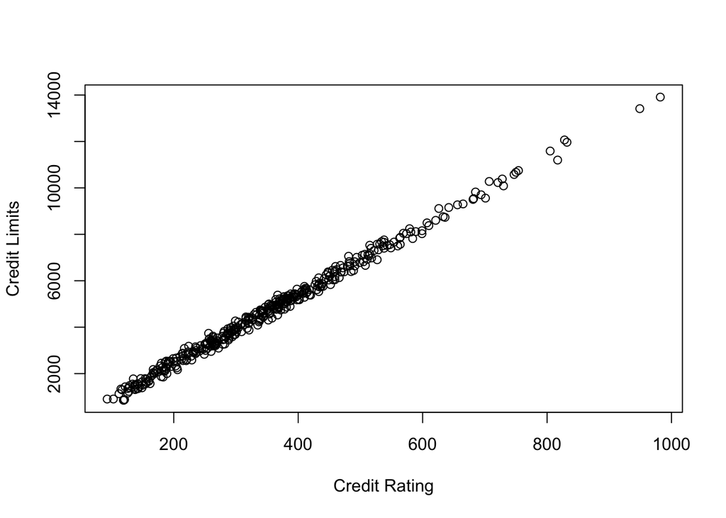

```r
a <- read.csv("https://albums.yuanting.lu/sta126/data/credit.csv")
plot(a$Limit ~ a$Rating, xlab = "Credit Rating", ylab = "Credit Limits")
```

**Example 3.** Is there a relation between one’s credit ratings and one’s income?

**Example 4.** Is there a relation between one’s credit ratings and one’s age?

### Linear Correlation Coefficient

$$r = \dfrac{1}{n-1}\sum \left(\dfrac{x_i
- \bar x}{s_x}\right)\left(\dfrac{y_i - \bar y}{s_y}\right)$$

$x_i$: the x-value of the i-th data point  
$\bar x$: the mean of all x-values  
$s_x$: the standard deviation of all x-values  
$n$: sample size  
$\Sigma$: summation

**Example 5.** Calculate the linear correlation coefficient formula explained.

```r
x <- c(22, 21, 31, 35, 38)
y <- c(82, 91, 86, 95, 89)
```

Given the raw data in $x$ and $y$, the $R$ command for the linear correlation coefficient is

```r
cor(x, y)
```

Properties of the linear correlation coefficient $r$:

- $-1\le r \le 1$.
- When $r$ is close to $1$, there is strong positive linear correlation.
- When $r$ is close to $-1$, there is strong negative linear correlation.
- When $r$ is close to 0, there is little to no linear correlation.
- $r$ has no unit, i.e., it is a unitless measure of association.

**Example 6.** Find the linear correlation coefficient in the first three examples. Which pair has the strongest linear correlation?

### Correlation vs. Causation

In observational studies, we cannot establish a causal relationship with two correlated variables. Check out some of the [spurious correlations](https://www.tylervigen.com/spurious-correlations).

### Regression Line

$$\widehat{y} = b_1 x + b_0$$

Given the raw data $x$ and $y$, the least-squares linear regression line, can be found by the $R$ command

```r
lm(y ~ x)
```

**Example 7.** Find the linear regression lines between credit limits and credit ratings. What is the expected limit for someone whoes credit rating is 900?

```r
lm(a$Limit ~ a$Rating)
```

```
##
## Call:
## lm(formula = a$Limit ~ a$Rating)
##
## Coefficients:
## (Intercept)     a$Rating
##     -542.93        14.87
```

**Example 8.** One of the built-in datasets in $R$ is trees.

- Type `trees` in the $R$ console to see the data.
- Type `?trees` to see the details information about the data.

Questions:

1. Is there a correlation between the volume and the diameter of the trees?
2. Find the least-squares linear regression line.
3. Interpret the slope and the $y$-intercept in the regression line.
4. Predict the mean volume of a tree that has a diameter of 16.5 inches.

Be aware of the **extrapolation** issue. Extrapolation is the process of predicting unknown values by extending existing data beyond its original range, assuming the observed trends will continue outside the initial range.

### Critical Value

If the absolute value of a linear correlation coefficient is larger than the critical value in the table, we believe there exists a linear relation between the two variables.

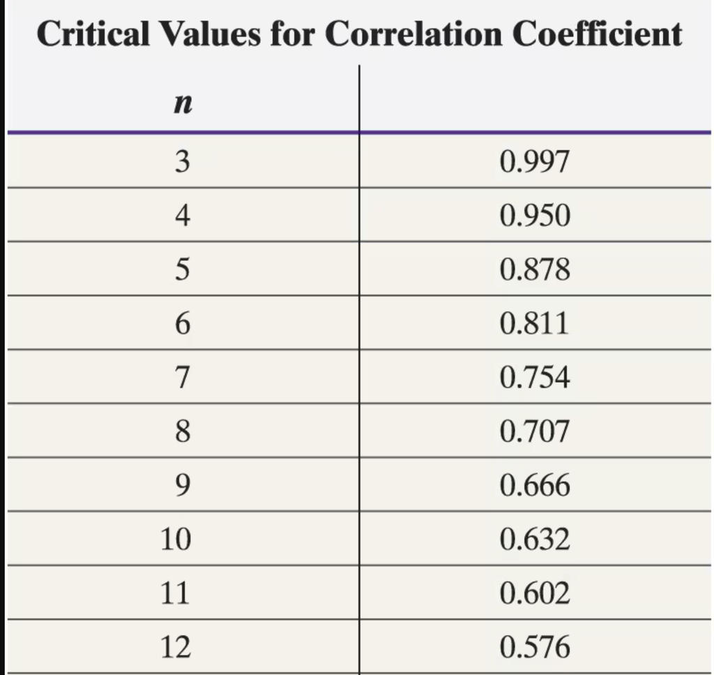

**Example 9.** Do we believe there is a linear relation between the two variables?

```r
x <- c(3, 5, 7, 9, 11)
y <- c(0, 2, 3, 6, 9)
```